# RAORANE_ENVS363_563_Assignment1_201741048

# Installing Packages

```r
#Declaring libraries
library(sf)
library(ggplot2)
library(raster)
library(terra)
library(exactextractr)
library(dplyr)
library(RColorBrewer)
library(classInt)
library(tmap)
```

# Your Annotated Code Task 1

```r
#importing, plotting and checking crs of tif file for 2020
popraster2020 <- rast("C:/Users/Aanand/Desktop/ENVS363+563/gds-main/data/China/gpw_v4_population_count_rev11_2020_2pt5_min.tif")


#plot(popraster2020$gpw_v4_population_count_rev11_2020_2pt5_min)
crs(popraster2020)
```

```
[1] "GEOGCRS[\"WGS 84\",\n    ENSEMBLE[\"World Geodetic System 1984 ensemble\",\n        MEMBER[\"World Geodetic System 1984 (Transit)\"],\n        MEMBER[\"World Geodetic System 1984 (G730)\"],\n        MEMBER[\"World Geodetic System 1984 (G873)\"],\n        MEMBER[\"World Geodetic System 1984 (G11…
```

```r
#importing,plotting and crs check of tif file for 2010
popraster2010 <- rast("C:/Users/Aanand/Desktop/ENVS363+563/gds-main/data/China/gpw_v4_population_count_rev11_2010_2pt5_min.tif")

#plot(popraster2010$gpw_v4_population_count_rev11_2010_2pt5_min)
crs(popraster2010)
```

```
[1] "GEOGCRS[\"WGS 84\",\n    ENSEMBLE[\"World Geodetic System 1984 ensemble\",\n        MEMBER[\"World Geodetic System 1984 (Transit)\"],\n        MEMBER[\"World Geodetic System 1984 (G730)\"],\n        MEMBER[\"World Geodetic System 1984 (G873)\"],\n        MEMBER[\"World Geodetic System 1984 (G11…
```

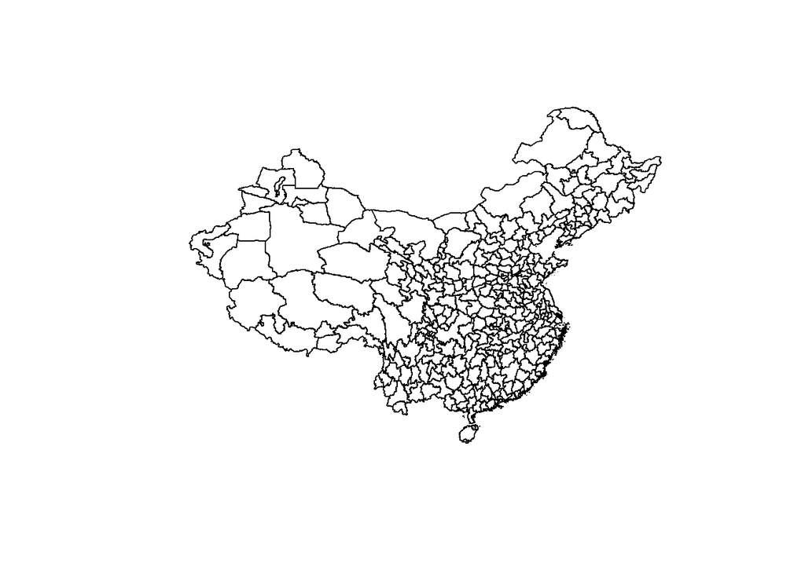

```r
#import,plot and crs check of shapefile of region level 2
shapedata <- read_sf("C:/Users/Aanand/Desktop/ENVS363+563/gds-main/data/China/gadm36_CHN_2.shp")
plot(shapedata$geometry)
```

```r
crs(shapedata)
```

```
[1] "GEOGCRS[\"WGS 84\",\n    DATUM[\"World Geodetic System 1984\",\n        ELLIPSOID[\"WGS 84\",6378137,298.257223563,\n            LENGTHUNIT[\"metre\",1]]],\n    PRIMEM[\"Greenwich\",0,\n        ANGLEUNIT[\"degree\",0.0174532925199433]],\n    CS[ellipsoidal,2],\n        AXIS[\"geodetic latitude …
```

```r
#crop and mask the raster data for 2020
popraster2020_crop <- crop(popraster2020, shapedata)
popraster2020_mask <- mask(popraster2020_crop, shapedata)

#to extract mean data
#have used progress as False so that in HTML file it will not show the extract progress
extractdata <- exact_extract(popraster2020_mask, shapedata, c("mean"),progress=FALSE)

#adding column to shapedata
shapedata$avg_density <- extractdata

#to check first initial records
head(shapedata$avg_density)
```

```
[1] 6534.004 9285.765 9702.840 7499.950 3071.215 5227.932
```

```r
#create break for map 1 according to the avg density
#here prefered quantile since its the best appraoch for balancing data distribution, also helps here to interpret the map easily.
e_breaks <- classIntervals(shapedata$avg_density, n = 4, style = "quantile")

# Assign the class breaks to the data
shapedata$e_breaks <- cut(shapedata$avg_density, e_breaks$brks)


#Create map using ggplot

# Define a color palette for visualizing data.
num_bins <-4
cmap <- brewer.pal(num_bins, "PuBuGn")

map1<-ggplot() +
  geom_sf(data = shapedata, aes(fill = e_breaks)) +
    theme_void() +
  theme(legend.position = "bottom") +
  scale_fill_manual(values = cmap, name = "Avg Density", labels = c("Very Low", "Low", "Mediun", "High"),na.value = "transparent")+
  labs(
    title = "Population Density by Region 2020"
  )
```

# Your Annotated Code Task 2

```r
#crop and mask the raster data for 2010
popraster2010_crop <- crop(popraster2010, shapedata)
popraster2010_mask <- mask(popraster2010_crop, shapedata)


#difference between 2 raster data
population_change_raster <- popraster2020_mask-popraster2010_mask

#extract difference
population_change_value <- extract(population_change_raster,shapedata)

#summary of new raster data
summary(population_change_value)
```

```
       ID        gpw_v4_population_count_rev11_2020_2pt5_min
 Min.   :  1.0   Min.   :-32613.4
 1st Qu.:148.0   1st Qu.:     0.0
 Median :227.0   Median :     2.4
 Mean   :215.5   Mean   :   201.5
 3rd Qu.:300.0   3rd Qu.:    45.3
 Max.   :344.0   Max.   :572861.0
```

```r
#define breaks and label
breaks<-c(-Inf,-100,0,200,Inf)
labels<-c("Decline","Neutral","Growth","High Growth")

#converted listed raster values to numeric
population_change_numeric <- as.numeric(unlist(population_change_value))

#reclassify the numberic value of the raster data between 2020 and 2010
classified_raster <- cut(population_change_numeric,breaks=breaks,labels=labels,include.lowest=TRUE)

classified_raster<-raster(population_change_raster)

#setting the color
colorpalette<- c("Decline" = "red","Neutral"= "yellow","Growth"="green","High Growth"="blue")

#creating map
map2<-tm_shape(classified_raster)+
  tm_raster(style="pretty", palette = colorpalette)+
  tm_shape(shapedata)+
  tm_borders()+
  tm_layout(title ="Categorial Change in Population Density 2010-2020",
            frame = FALSE,
            legend.outside = TRUE,
            legend.outside.position = "right")+
  tm_scale_bar(position=c("left", "bottom"))+tm_compass()
```

# Maps

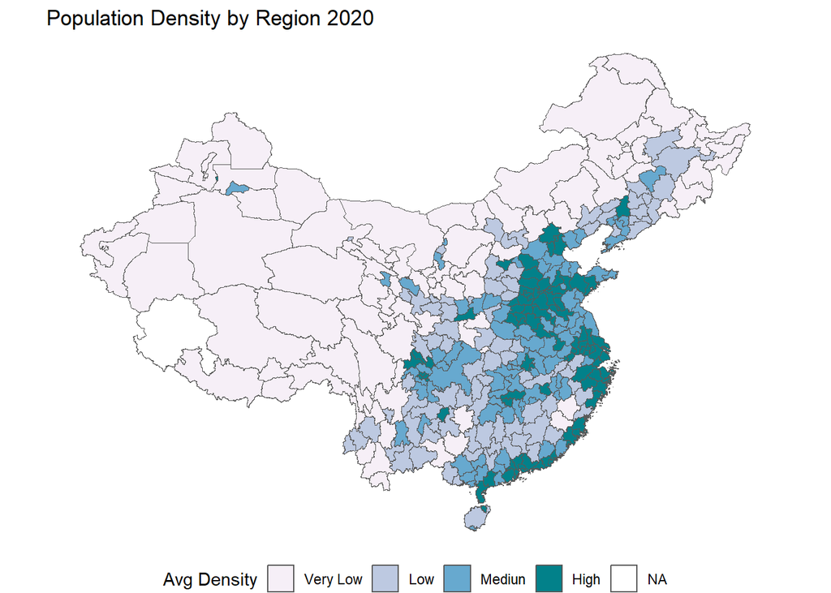

```r
#Displaying Map1 and Map 2
print(map1)
```

[output not shown]

[figure not shown]

[output not shown]

```r
tm_view(map2)
```

# Up to 500 words which should address the following questions.

1. What value is associated with each pixel?
2. Which CRS are you using? Justify your answer.
3. What is Map 1 saying about population density in China?
4. Which categorical divisions (Decline, Neutral, Growth and High Growth) did you chose for Map 2 and why?

Commencing with the answer to above questions are as follows:

2] CRS used for this assignment is likely a standard geographic coordinates system named as WGS84 (EPSG:4326) [note can be checked using command i.e. (crs(rast data file)). This defines how spatial data is interpreted, since it’s widely used for global datasets, including population data. This choice ensures accurate spatial representation for the entire dataset.

3] In Map 1 a detailed view of population density in China at the regional level 2 for year 2020. It highlights variations in population density across different regions. Areas with higher population density are depicted with darker colors, while lighter colors represent lower population density. This maps allow us to identify regions with high, moderate, and low population density in China. As we can see in my map1 it tells us that high dense populated regions are in south-east region of China. Overall, China’s majority west and north region has very low densely populated region.

“Decline” signifies regions where population density has decreased over the decade.

“Neutral” indicates areas where population density has remained relatively stable.

“Growth” represents region with a moderate increase in population density.

“High growth” is used for areas with a substantial increase in population density.

In Summary, the assignment involves the analysis and visualization of population density changes in China over a decade. It employs a well-defined CRS to ensure data compatibility and provides two maps that offers insights into the nature of these changes.